# warmup01-ray-yuan.Rmd

Ray Yuan

February 3, 2019

## Star Wars

#### Bo Keevil

[figure not shown]

A famous quote by Bo Keevil: “It’s out of control. We’re not going to make it.”

| Description | Value |
| --- | --- |
| Species | Kel Dor |
| Gender | Male |
| Eye Color | Black |
| Skin Color | Yellow |

## Cooking Recipe:Plush Coconut Cake

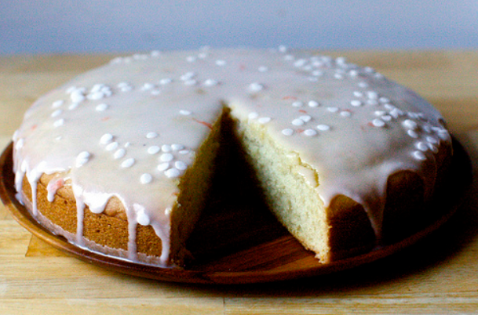

### Ingredients

- 2 cups plus 3 tablespoons (285 grams) all-purpose flour
- 1 1/2 teaspoons baking soda
- 1/2 teaspoon fine sea salt
- 1 cup (200 grams) granulated sugar
- 1/2 cup (110 grams) coconut oil, warmed just enough to liquefy
- 1 1/2 cups full- or low-fat coconut milk
- 1 tablespoon (15 ml) plain vinegar

### Kitchen Tools

- 9-inch round cake pan
- parchment paper
- large mixing bowl
- whisk

### Instructions

1. Heat oven to 350 degrees F. Line the bottom of 9-inch round cake pan with a fitted round of parchment paper and coat the bottoms and sides with nonstick cooking spray.
2. Whisk together flour, baking soda, salt and granulated sugar in the bottom of a large mixing bowl. Add coconut oil, coconut milk, and vinegar and whisk until batter is smooth.
3. Pour into prepared pan. Bake for 25 to 30 minutes, or until the top is springy
4. Cool the cake in the pan on a wire rack for 10 minutes, then cut around it with a knife to ensure it is loosened and flip it out onto a cooling rack to cool the rest of the way.
5. For the glaze, whisk together 3/4 cup powdered sugar with 1 to 2 tablespoons of the leftover coconut milk, adding a little at a time, until it is smooth but not too runny.
6. Once cake is fully cool, spread over the top of the cake and smooth to the edges

### Variations In Recipe

- If you’re not deeply into coconut, use a flavorless oil or vegan butter instead of coconut oil
- You can choose to add some white confetti sprinkles or toasted coconut chips for presentation.

> Season: There is no season for when this dessert is commonly eaten, since it really is just a fantastic everyday snack cake.

## Euclidean Distance

### Definition [edit]

The **Euclidean distance** between points **p** and **q** is the length of the line segment connecting them ($\overline{\mathbf{pq}}$).

In Cartesian coordinates, if **p** = $(p_{1}, p_{2},..., p_{n})$ and **q** = $(q_{1}, q_{2},..., q_{n})$ are two points in Euclidean n-space, then the distance (d) from **p** to **q**, or from **q** to **p** is given by the Pythagorean formula:

$$\begin{align}
d(\mathbf{p},\mathbf{q}) = d(\mathbf{q},\mathbf{p})&=\sqrt{(q_{1}-p_{1})^2 + (q_{2}-p_{2})^2 +...+(q_{n}-p_{n})^2} \\ &=
\sqrt{\sum_{i=1}^{n}(q_{i}-p_{i})^{2}}
\end{align}$$
The position of a point in a Euclidean n-space is a Euclidean vector. So, **p** and **q** may be represented as Euclidean vectors, starting from the origin of the space (initial point) with their tips (terminal points) ending at the two points. The **Euclidean norm**, or **Euclidean length**, or **magnitude** of a vector measures the length of the vector:
$$\begin{align}
\lVert \mathbf{p} \rVert = \sqrt{p_{1}^{2}+p_{2}^{2}+...+p_{n}^{2}}=\sqrt{\mathbf{p}\cdot\mathbf{p}} ,
\end{align}$$

where the last expression involves the dot product.